# Praktikum 6 Anreg

### QQ plot

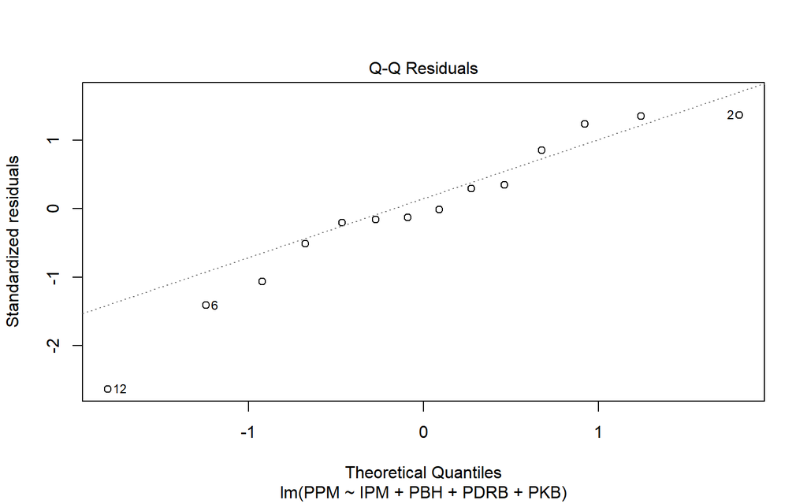

```r
plot(model2,2)
```

## Uji Formal

### Nilai harapan sisaan sama dengan nol

```r
t.test(model2$residuals,mu = 0,conf.level = 0.95)
```

```
##
##  One Sample t-test
##
## data:  model2$residuals
## t = -4.933e-17, df = 13, p-value = 1
## alternative hypothesis: true mean is not equal to 0
## 95 percent confidence interval:
##  -2.649462  2.649462
## sample estimates:
##     mean of x
## -6.049848e-17
```

Nilai p pada uji t sama dengan 1 yang lebih besar dari alpha 5%, sehingga dinyatakan asumsi nilai harapan sisaan sama dengan nol terpenuhi

### Ragam sisaan homogen

```r
bptest(model2)
```

```
##
##  studentized Breusch-Pagan test
##
## data:  model2
## BP = 7.9216, df = 4, p-value = 0.09449
```

### Sisaan saling bebas

```r
dwtest(model2)
```

```
##
##  Durbin-Watson test
##
## data:  model2
## DW = 2.667, p-value = 0.8141
## alternative hypothesis: true autocorrelation is greater than 0
```

Nilai p pada uji durbin watson sama dengan 0.814 yang lebih besar dari alpha 5%, sehingga dinyatakan asumsi sisaan saling bebas terpenuhi

### Normalitas Sisaan

```r
shapiro.test(model2$residuals)
```

```
##
##  Shapiro-Wilk normality test
##
## data:  model2$residuals
## W = 0.94542, p-value = 0.4921
```

Nilai p pada uji shapiro wilk sama dengan 0.4921 yang lebih besar dari alpha 5%, sehingga dinyatakan asumsi normalitas sisaan terpenuhi

Semua asumsi sisaan terpenuhi, tetapi model masih buruk, kemungkinan karena keberadaan amatan yang tidak biasa seperti pencilan, leverage, atau amatan berpengaruh

# Pemeriksaan Amatan Tidak Biasa

```r
#fungsi
ri_stud <- rstudent(model2)
ri_stan <- rstandard(model2)
hii_fungsi <- hatvalues(model2)

#manual
X <- model.matrix(model2)
X_inv_xt <- X %*% solve(t(X) %*% X) %*% t(X)
hii_manual <- diag(X_inv_xt)
anova_model <- anova(model2)
s <- sqrt(anova_model["Residuals", "Mean Sq"])
ei <- model2$residuals
ri_manual <- ei/(s*sqrt(1-hii_manual))

nilai <- data.frame(ri_stud, ri_stan, ri_manual, hii_fungsi, hii_manual)
nilai
```

```
##        ri_stud     ri_stan   ri_manual hii_fungsi hii_manual
## 1  -0.15353674 -0.16261090 -0.16261090  0.6718055  0.6718055
## 2   1.45079346  1.36918757  1.36918757  0.3494742  0.3494742
## 3  -0.12232956 -0.12962891 -0.12962891  0.1271960  0.1271960
## 4  -0.19716436 -0.20861814 -0.20861814  0.2924706  0.2924706
## 5  -0.01646138 -0.01745963 -0.01745963  0.1450868  0.1450868
## 6  -1.50833672 -1.41164976 -1.41164976  0.3829498  0.3829498
## 7   0.27815383  0.29361033  0.29361033  0.5071792  0.5071792
## 8   1.28246645  1.23886063  1.23886063  0.3189796  0.3189796
## 9  -1.06952819 -1.06107964 -1.06107964  0.1827965  0.1827965
## 10 -0.48686799 -0.50891690 -0.50891690  0.5072987  0.5072987
## 11  1.42761895  1.35178583  1.35178583  0.3555038  0.3555038
## 12 -5.21644400 -2.63727154 -2.63727154  0.6287502  0.6287502
## 13  0.33205479  0.34979501  0.34979501  0.2204124  0.2204124
## 14  0.84235401  0.85628392  0.85628392  0.3100967  0.3100967
```

## Pencilan

```r
for (i in 1:dim(nilai)[1]){
  absri <- abs(nilai[,2])
  pencilan <- which(absri > 2)
}
pencilan
```

```
## [1] 12
```

Amatan ke-12 terdeteksi sebagai pencilan

## Leverage

```r
n <- dim(dt)[1]
p <- length(model2$coefficients)

for (i in 1:dim(nilai)[1]){
  cutoff <- 2*p/n
  titik_leverage <- which(hii_fungsi > cutoff)
}
titik_leverage
```

```
## named integer(0)
```

Tidak terdeteksi titik amatan yang ekstrem

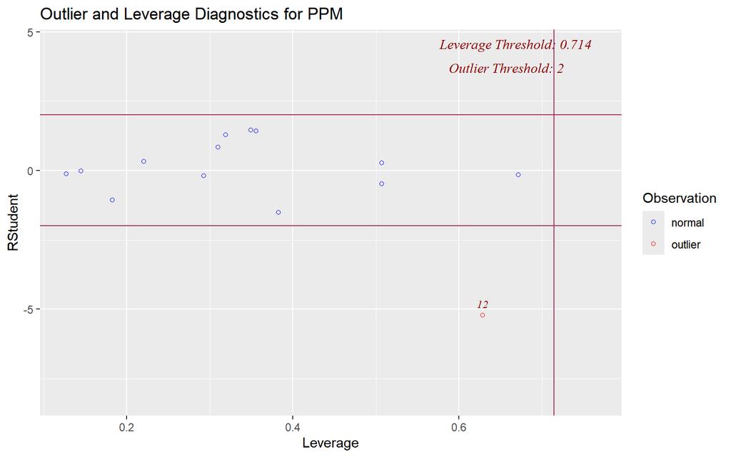

```r
ols_plot_resid_lev(model2)
```

Plot yang terbentuk dari fungsi `ols_plot_resid_lev()` Amatan ke-12 adalah outlier murni (pencilan), tetapi bukan leverage point, sehingga belum bisa langsung disebut sebagai titik berpengaruh (influential observation).

## Amatan Berpengaruh

### Jarak Cook

```r
di <- cooks.distance(model2)
f <- qf(0.05,p,n-p, lower.tail = F)
data.frame(di, di>f)
```

```
##              di di...f
## 1  1.082534e-02  FALSE
## 2  2.014218e-01  FALSE
## 3  4.897682e-04  FALSE
## 4  3.598089e-03  FALSE
## 5  1.034679e-05  FALSE
## 6  2.473462e-01  FALSE
## 7  1.774374e-02  FALSE
## 8  1.437731e-01  FALSE
## 9  5.036904e-02  FALSE
## 10 5.333394e-02  FALSE
## 11 2.015904e-01  FALSE
## 12 2.355872e+00  FALSE
## 13 6.918760e-03  FALSE
## 14 6.591351e-02  FALSE
```

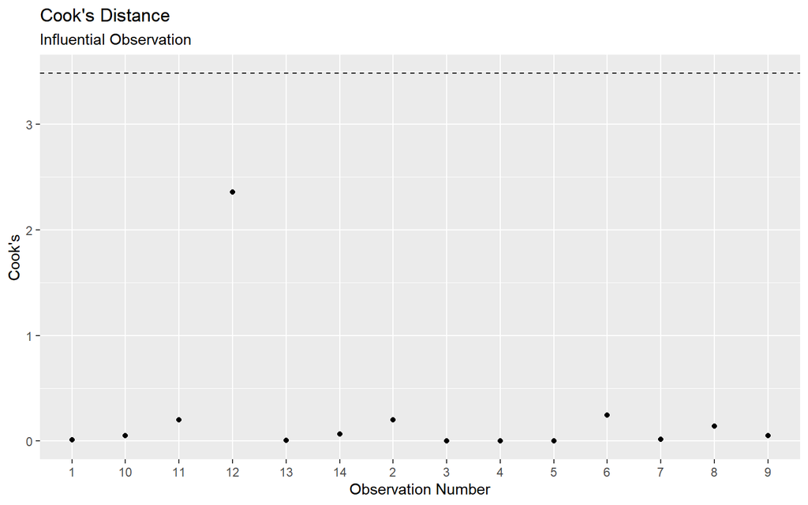

```r
cooks_crit = f
model_cooks <- cooks.distance(model2)
df <- data.frame(obs = names(model_cooks),
                 cooks = model_cooks)
ggplot(df, aes(y = cooks, x = obs)) +
  geom_point() +
  geom_hline(yintercept = cooks_crit, linetype="dashed") +
  labs(title = "Cook's Distance",
       subtitle = "Influential Observation ",
       x = "Observation Number",
       y = "Cook's")
```

Pemeriksaan amatan berpengaruh dengan jarak cook tidak dihasilkan nilai yang melebihi ambang batas

### DFBETAS

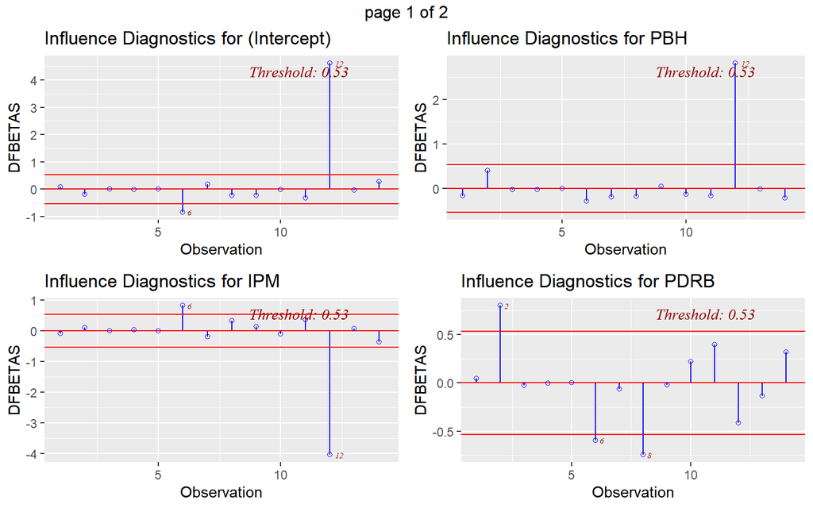

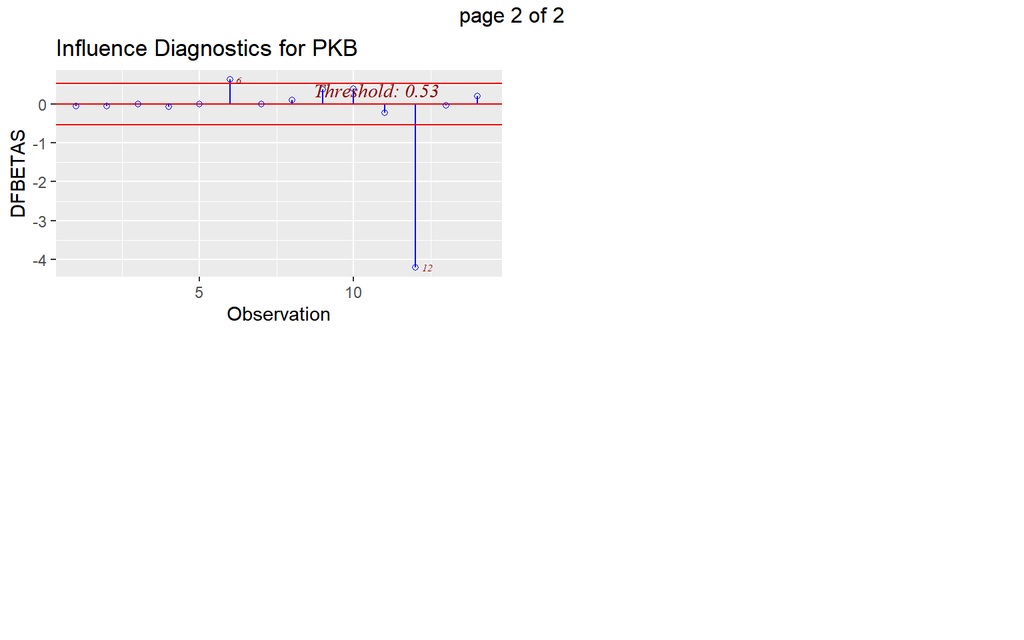

```r
ols_plot_dfbetas(model2)
```

Hasil DFBETAS akan menunjukkan pengaruh observasi terhadap setiap koefisien regresi, sehingga ada output untuk setiap parameter regresi. DFBETAS mengukur seberapa besar koefisien regresi berubah jika suatu observasi dihapus dari model.

### DFFITS

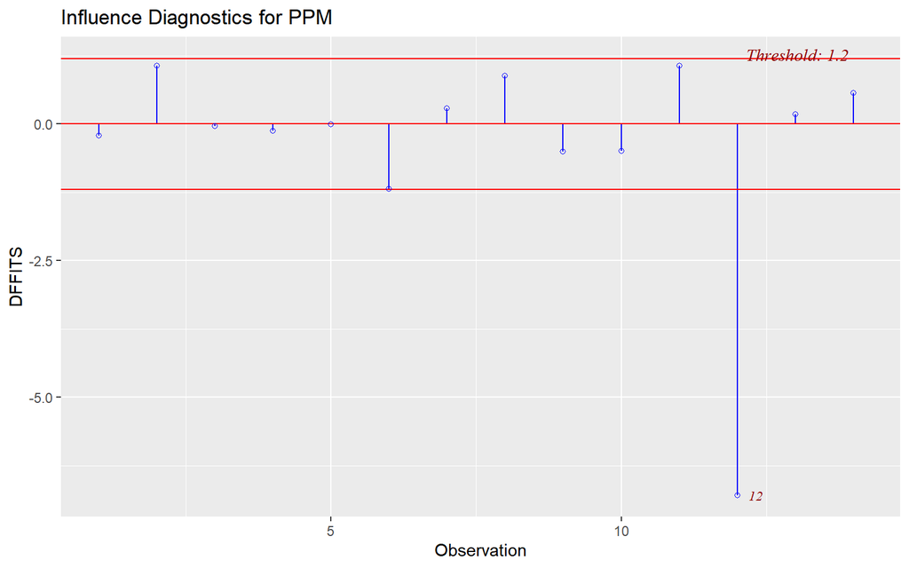

```r
ols_plot_dffits(model2)
```

Hasil DFFITS menunjukkan pengaruh observasi terhadap nilai prediksi Y, sehingga hanya menghasilkan satu output. DFFITS mengukur seberapa besar nilai prediksi $\hat{Y}_i$ berubah jika suatu observasi dihapus dari model, sehingga lebih tepat digunakan jika ingin melihat pengaruh observasi terhadap hasil model secara keseluruhan

```r
DFFITSi <- dffits(model2)

amatan_berpengaruh <- vector("list", dim(nilai)[1])
for (i in 1:dim(nilai)[1]) {
  cutoff <- 2 * sqrt((p / n))
  amatan_berpengaruh[[i]] <- which(abs(DFFITSi) > cutoff)
}
berpengaruh <- unlist(amatan_berpengaruh)
amatan_berpengaruh <- sort(unique(berpengaruh))
amatan_berpengaruh
```

```
## [1] 12
```

Amatan ke-12 termasuk amatan berpengaruh sehingga sangat riskan jika disisihkan. Perlu ditelusuri lebih lanjut

# Pemodelan Penyisihan Amatan

```r
# gunakan peubah penjelas yang sudah diseleksi

dt1 <- dt %>% slice(-12)
model3 <- lm(PPM ~ IPM + PBH + PDRB + PKB, dt1)

dt2 <- dt %>% slice(-12)
model4 <- lm(PPM ~ IPM + PBH + PDRB + PKB, dt2)

dt3 <- dt %>% slice(-12)
model5 <- lm(PPM ~ IPM + PBH + PDRB + PKB, dt3)

dt4 <- dt %>% slice(-c(12))
model6 <- lm(PPM ~ IPM + PBH + PDRB + PKB, dt4)

dt5 <- dt %>% slice(-c(12))
model7 <- lm(PPM ~ IPM + PBH + PDRB + PKB, dt5)

dt6 <- dt %>% slice(-c(21))
model8 <- lm(PPM ~ IPM + PBH + PDRB + PKB, dt6)

dt7 <- dt %>% slice(-c(12))
model9 <- lm(PPM ~ IPM + PBH + PDRB + PKB, dt7)
```

```r
get_metrics <- function(model) {
  adj_r2 <- summary(model)$adj.r.squared
  sse <- sum(model$residuals^2)
  return(c(adj_r2, sse))
}

model_metrics <- data.frame(
  Model = c("Model 2", "Model 3", "Model 4", "Model 5", "Model 6",
            "Model 7", "Model 8", "Model 9"),
  Adjusted_R2 = sapply(list(model2, model3, model4, model5,
                            model6, model7, model8, model9),
                       function(m) get_metrics(m)[1]),
  SSE = sapply(list(model2, model3, model4, model5,
                    model6, model7, model8, model9),
               function(m) get_metrics(m)[2])
)

print(model_metrics)
```

```
##     Model Adjusted_R2       SSE
## 1 Model 2   0.1087689 273.73553
## 2 Model 3   0.7438432  62.19268
## 3 Model 4   0.7438432  62.19268
## 4 Model 5   0.7438432  62.19268
## 5 Model 6   0.7438432  62.19268
## 6 Model 7   0.7438432  62.19268
## 7 Model 8   0.1087689 273.73553
## 8 Model 9   0.7438432  62.19268
```

```r
stargazer(model2, model4, model9, type = "text", font.size = "small",
          report = "vc*p")
```

```
##
## ===============================================================================
##                                         Dependent variable:
##                     -----------------------------------------------------------
##                                                 PPM
##                            (1)                (2)                  (3)
## -------------------------------------------------------------------------------
## IPM                      -0.126             1.912**              1.912**
##                         p = 0.903          p = 0.018            p = 0.018
##
## PBH                       0.575              -0.280               -0.280
##                         p = 0.364          p = 0.441            p = 0.441
##
## PDRB                     0.0004              0.001                0.001
##                         p = 0.545          p = 0.137            p = 0.137
##
## PKB                       0.341             0.779***             0.779***
##                         p = 0.133          p = 0.0004           p = 0.0004
##
## Constant                 -3.641           -165.042***          -165.042***
##                         p = 0.960          p = 0.008            p = 0.008
##
## -------------------------------------------------------------------------------
## Observations               14                  13                   13
## R2                        0.383              0.829                0.829
## Adjusted R2               0.109              0.744                0.744
## Residual Std. Error  5.515 (df = 9)      2.788 (df = 8)       2.788 (df = 8)
## F Statistic         1.397 (df = 4; 9) 9.712*** (df = 4; 8) 9.712*** (df = 4; 8)
## ===============================================================================
## Note:                                               *p<0.1; **p<0.05; ***p<0.01
```